# Introductory ggplot2 Homework

The data for this assignment is provided in the CodeClanData package.

- `qb_revenue_breakdown`
- `qb_monthly_sales`
- `qb_competitors`
- `qb_device_data`

Take a little time before you start to familiarise yourself with the data.

# Introductory ggplot2 Homework

```r
library(CodeClanData)
library(tidyverse)
```

# MVP

## Part 1

**Question 1.**  
Take the data in the dataset `qb_revenue_breakdown` and make a stacked bar chart showing the sources of revenue across the two years in the dataset.

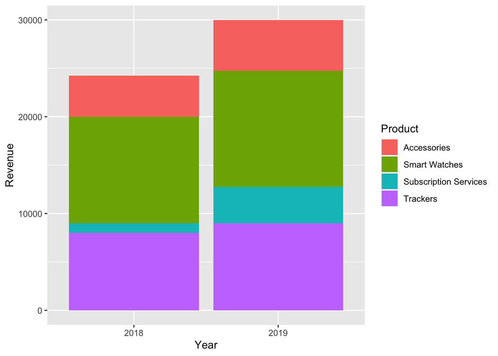

```r
#View(qb_revenue_breakdown)

ggplot(qb_revenue_breakdown) +
    geom_bar(aes(x = Year, y = Revenue, fill = Product), stat = "identity")
```

**Question 2.**  
Make a line chart showing monthly sales of the “flagship product” - the ‘KwikBit Unit 1’ - over the last year. This data is inside `qb_monthly_sales`, but you will need to use `filter()` or `subset()` (base `R)`.

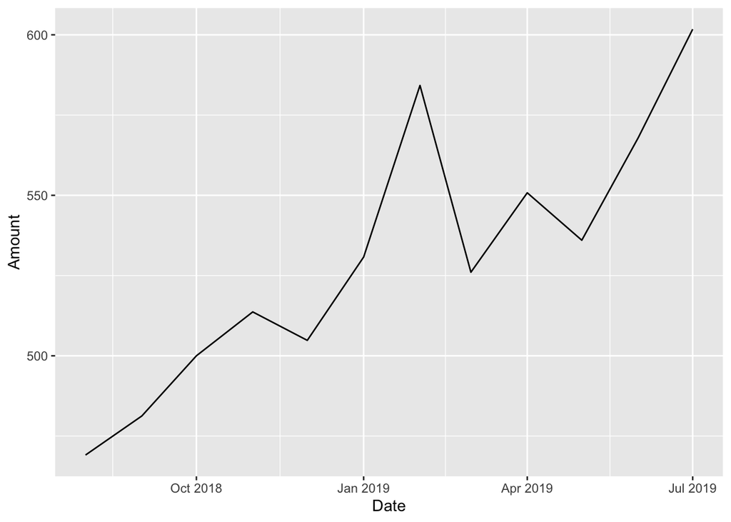

```r
#View(qb_monthly_sales)

#qb_monthly_sales %>%
#distinct(Cashflow)

qb_monthly_sales %>%
  filter(Cashflow == "Kwikbit Unit 1 Sales") %>%

  ggplot(aes(x = Date, y = Amount)) +
  geom_line()
```

**Question 3.**  
Make a line chart showing monthly revenue and costs over the last year. This data is also in `qb_monthly_sales`.

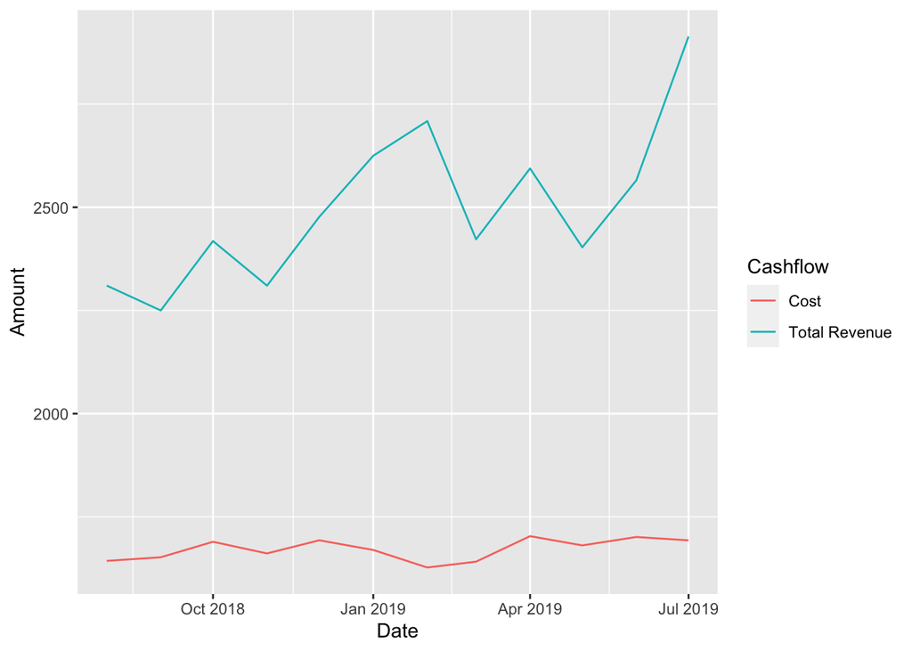

```r
qb_monthly_sales %>%
  filter(Cashflow == "Total Revenue" |
           (Cashflow == "Cost")) %>%

  ggplot(aes(x = Date, y = Amount, colour = Cashflow)) +
  geom_line()
```

**Question 4.**  
Show annual sales of personal fitness trackers over the last 5 years broken down by company as a ribbon plot (use `geom_area`). This data is in `qb_competitors`.

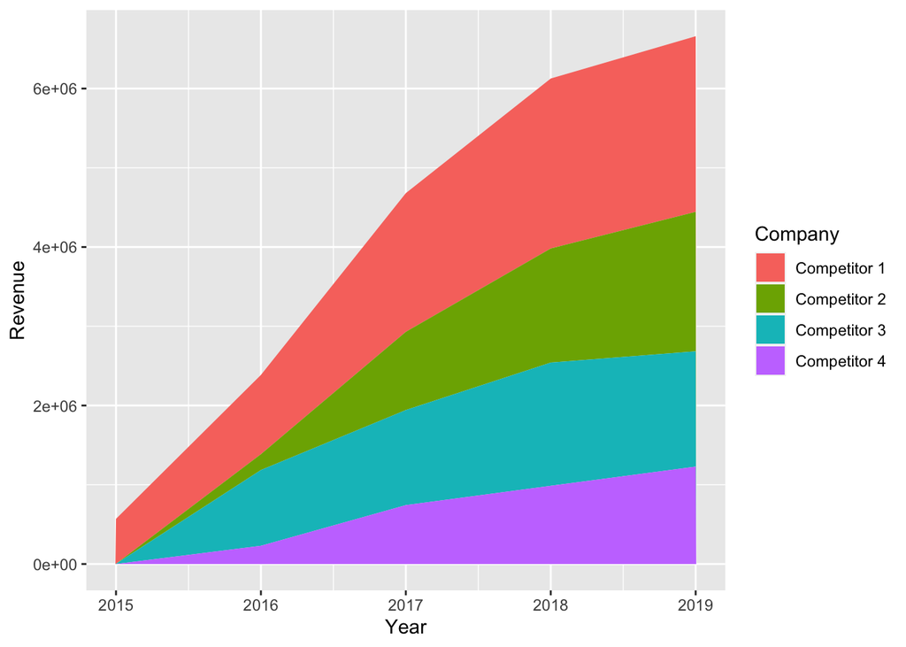

```r
#View(qb_competitors)
#head(qb_competitors)

qb_competitors %>%
  ggplot(aes(x = Year, y = Revenue, fill = Company)) +
  geom_area()
```

**Question 5.**  
Now show the sales from the four competitors as a line graph. Include an extra layer that shows the data points used to make the lines.

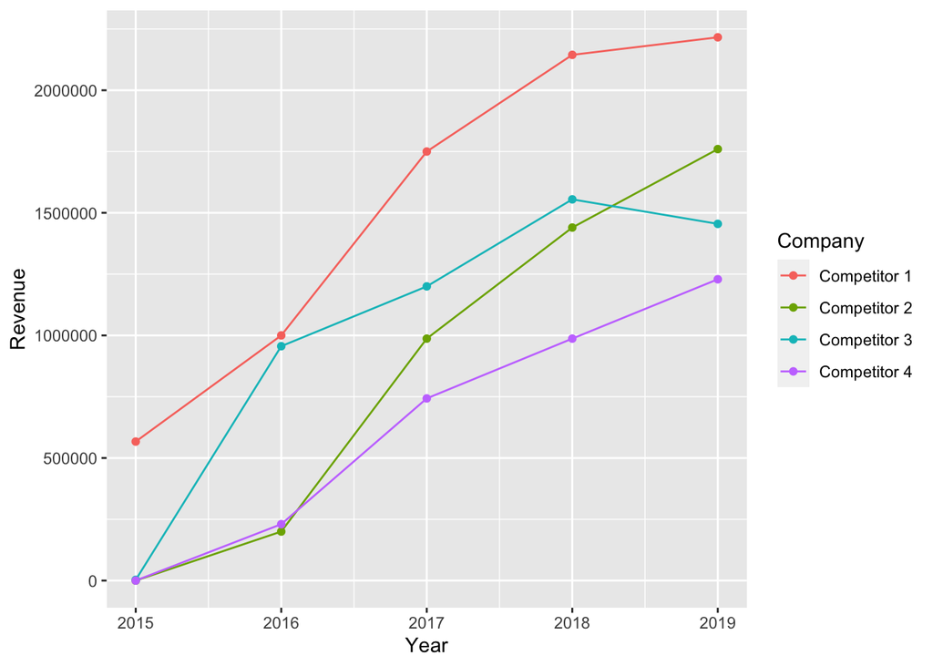

```r
qb_competitors %>%
  ggplot(aes(x = Year, y = Revenue, colour = Company)) +
  geom_line() +
  geom_point()
```

**Question 6.**  
Now the company wants to compare the number of steps that their device counts vs. their competitors. Make a line graph of the number of steps throughout time, and use faceting to compare between companies and people. The data for this is in `qb_device_data`.

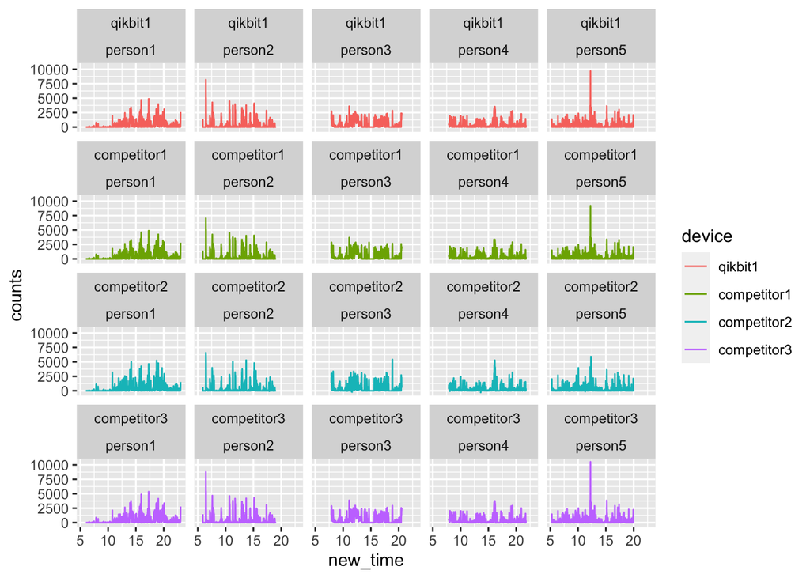

```r
#View(qb_device_data)
#head(qb_device_data)
#qb_device_data %>%
#  distinct(device)

device_with_time <- qb_device_data %>%
  mutate(new_time = hours + (mins/60))

device_with_time %>%
  ggplot(aes(x = new_time, y = counts, colour=device)) +
  geom_line() +
  facet_wrap(device ~ id)
```

## Part 2

**Question 1.**  
Take the plots that you produced in part one and now polish them by:

1. Adding appropriate labels
2. Changing the scales and coordinates when appropriate.
3. Applying a unified theme, which is described below:
- Graphs should have white backgrounds, and use colour sparingly.
- There should be faint grid lines.
- Font sizes should be ~12pt although titles should be slightly larger and axis labels can be slightly smaller.
- All plots should use colours from the following company colour scheme.

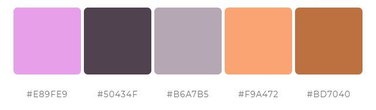

```r
col_scheme <- c("#E89FE9", "#50434F", "#B6A7B5", "#F9A472", "#BD7040")
```

**Question 1b**

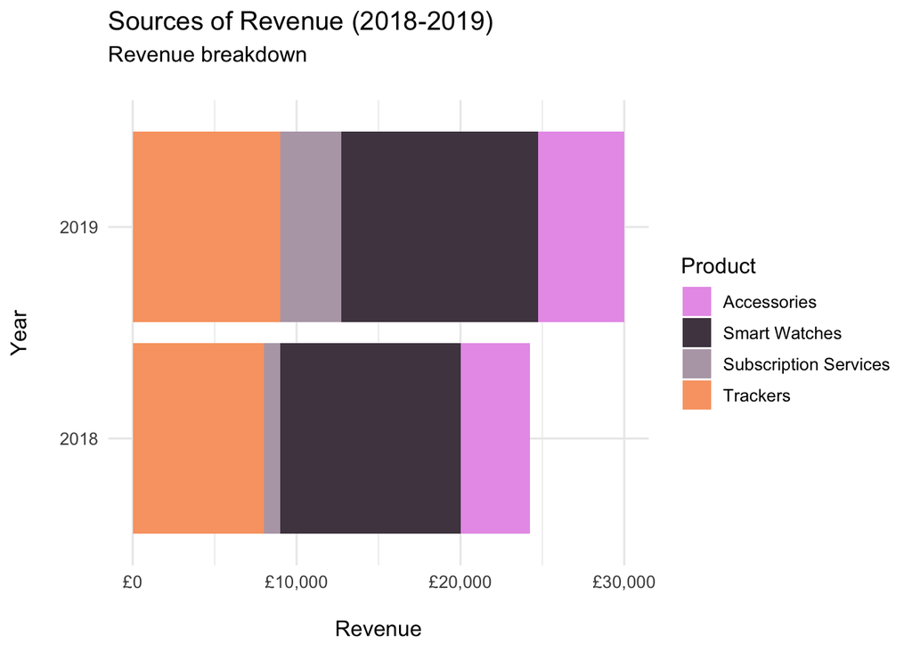

```r
col_scheme <- c("#E89FE9", "#50434F", "#B6A7B5", "#F9A472", "#BD7040")

ggplot(qb_revenue_breakdown) +
    geom_bar(aes(x = Year, y = Revenue, fill = Product) , stat = "identity") +
    scale_fill_manual( values = col_scheme)+
  coord_flip() +
  #?label_dollar
    scale_y_continuous(labels = scales::label_dollar(prefix = "£")) +
 ## scales::
  theme_minimal(base_size = 12) +
   labs(
    x = "Year\n",
    y = "\nRevenue",
    title = "Sources of Revenue (2018-2019)",
    subtitle = "Revenue breakdown\n",
  )
```

**Question 2b**

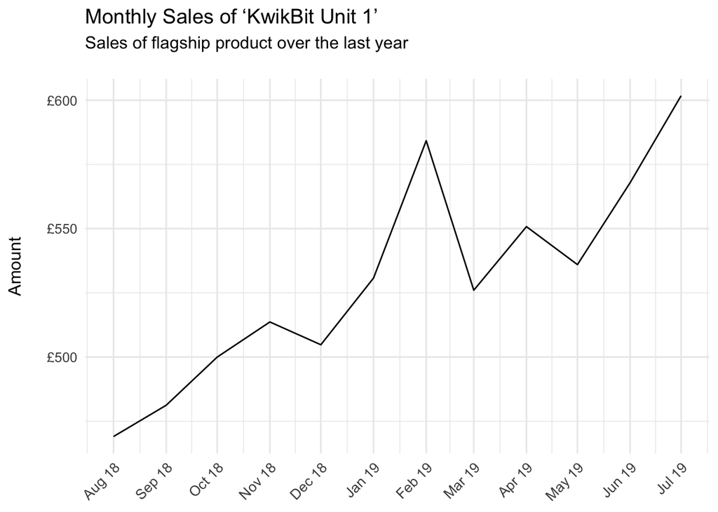

```r
qb_monthly_sales %>%
  filter(Cashflow == "Kwikbit Unit 1 Sales") %>%

  ggplot(aes(x = Date, y = Amount)) +
  geom_line() +
  theme_minimal(base_size = 12) +
    theme(axis.text.x = element_text(angle = 45, hjust = 1, size = 10))+

   scale_x_date(
    NULL,
    breaks = scales::breaks_width("1 months"),
    labels = scales::label_date("%b %y")
  ) +
  scale_y_continuous(labels = scales::label_dollar(prefix = "£")) +
  scale_colour_manual(values = col_scheme) +

  labs(
    x = "\nDate",
    y = "Amount\n",
   title = "Monthly Sales of ‘KwikBit Unit 1’",
    subtitle = "Sales of flagship product over the last year\n",
  )
```

**Question 3b**

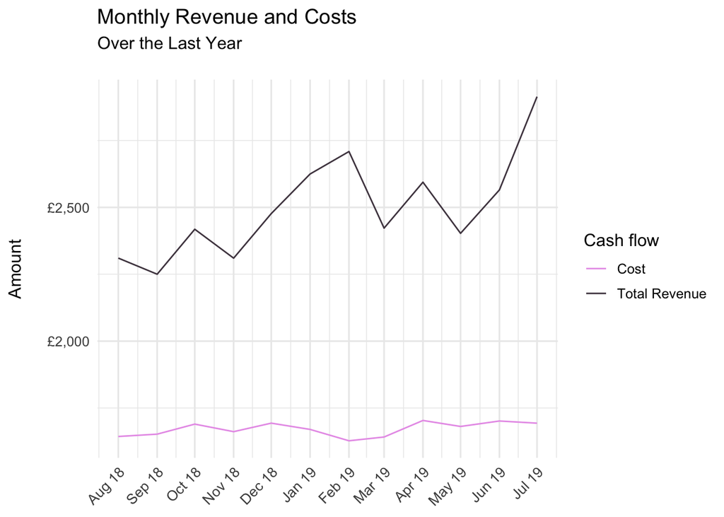

```r
qb_monthly_sales %>%
  filter(Cashflow == "Total Revenue" |
           (Cashflow == "Cost")) %>%

  ggplot(aes(x = Date, y = Amount, colour = Cashflow)) +
  geom_line() +
      scale_colour_manual( values = col_scheme) +
  theme_minimal(base_size = 12) +
  theme(axis.text.x = element_text(angle = 45, hjust = 1, size = 10))+
 # scale_y_continuous(labels = scales::comma) +
  scale_y_continuous(labels = scales::label_dollar(prefix = "£")) +
   scale_x_date(
    NULL,
    breaks = scales::breaks_width("1 months"),
    labels = scales::label_date("%b %y")
  ) +
  labs(
    x = "\nDate",
    y = "Amount\n",
    title = "Monthly Revenue and Costs",
    subtitle = "Over the Last Year\n",
    colour = "Cash flow",
  )
```

**Question 4b**

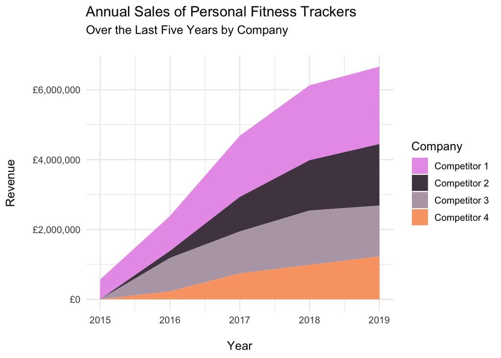

```r
qb_competitors %>%
  ggplot(aes(x = Year, y = Revenue, fill = Company)) +
  geom_area() +
        scale_fill_manual( values = col_scheme) +
  theme_minimal(base_size = 12) +
 #     scale_y_continuous(labels = scales::comma) +
  scale_y_continuous(labels = scales::label_dollar(prefix = "£")) +
  labs(
    x = "\nYear",
    y = "Revenue\n",
    title = "Annual Sales of Personal Fitness Trackers",
    subtitle = "Over the Last Five Years by Company\n",
  )
```

**Question 5b**

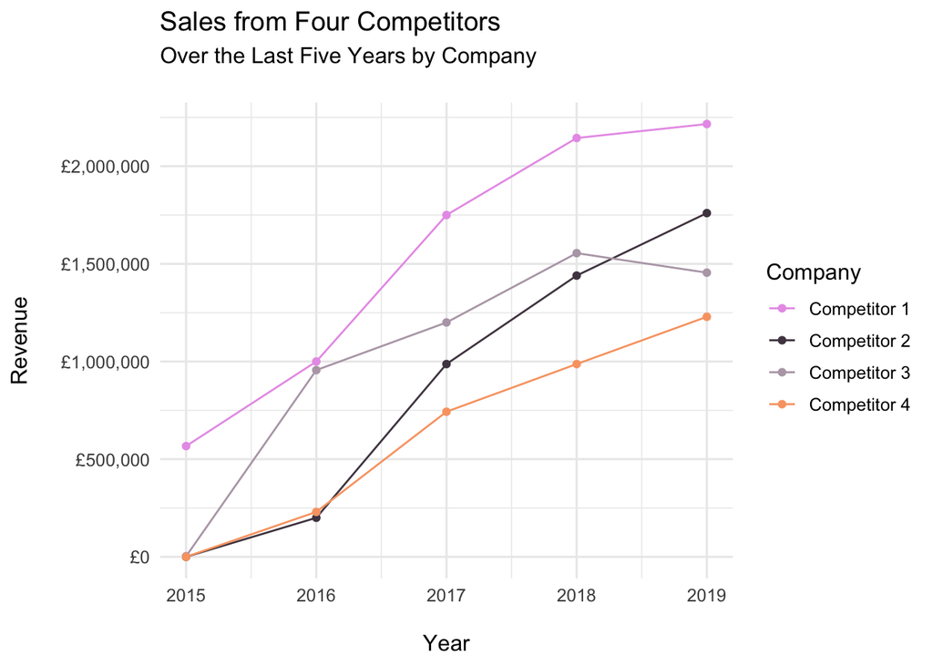

```r
qb_competitors %>%
  ggplot(aes(x = Year, y = Revenue, colour = Company)) +
  geom_line() +
  geom_point() +
        scale_colour_manual( values = col_scheme) +
  theme_minimal(base_size = 12) +
 #     scale_y_continuous(labels = scales::comma) +
   scale_y_continuous(labels = scales::label_dollar(prefix = "£")) +
 labs(
    x = "\nYear",
    y = "Revenue\n",
    title = "Sales from Four Competitors",
    subtitle = "Over the Last Five Years by Company\n",
  )
```

**Question 6b**

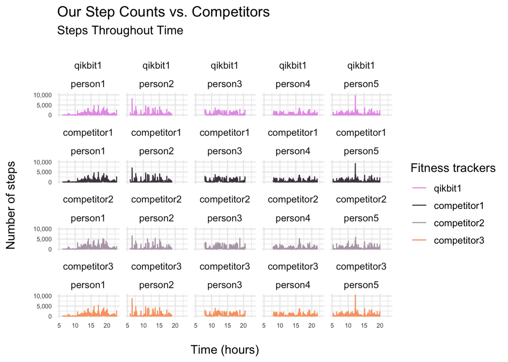

```r
device_with_time <- qb_device_data %>%
  mutate(new_time = hours + (mins/60))

device_with_time %>%
  ggplot(aes(x = new_time, y = counts, colour=device)) +
  geom_line() +
        scale_colour_manual( values = col_scheme) +

  theme_minimal(base_size = 12) +
    theme(axis.text = element_text(size = 6))+

      scale_y_continuous(labels = scales::comma,
                         breaks = c(0, 5000, 10000)) +
  facet_wrap(device ~ id)+
  labs(
    x = "\nTime (hours)",
    y = "Number of steps\n",
    title = "Our Step Counts vs. Competitors",
    subtitle = "Steps Throughout Time\n",
    colour = "Fitness trackers"
  )
```